# Curso Web Scraping Atividade Final

Denis de Oliveira Rodrigues

17/12/2021

## Descrição da página

A Secretaria Estadual de Saúde de Minas Gerais possui um portal com um variado conteúdo que inclui notícias, legislação, instruções, normativas e boletins de dados epidemiológicos. Sob o endereço eletrônico: saude.mg.gov.br, esses conteúdos são segmentados por quatro classes principais:  
a. Cidadão  
b. Gestor  
c. Profissional  
d. Sobre.

Além das seções, o site possui um vasto banco de notícias e uma área destinada às ações e notícias sobre coronavírus.

**Figura 1. Snapshot da página da Secretaria Estadual de Saúde de Minas Gerais**

[figure not shown]

Imagem

Sobre os boletins epidemiológicos, a Secretaria os utiliza frequentemente para atualizar sobre a situação da Dengue, Chikungunya e Zika no Estado. Estes boletins são disponilizados em formato PDF e também em XLSX, embora não necessariamente simultâneos.

Como o link sempre é diferente a cada nova postagem no site e também os arquivos que são publicados separados, não é possível ter uma única ação automatizada que busque rotineiramente o mesmo conteúdo. Além disso, os arquivos de óbitos e de casos são separados. A solução para este problema foi a motivação deste trabalho.

## Objetivo do *scraping*

Nosso objetivo para a atividade é buscar o boletim mais atualizado e gerar um mapa da situação atual da dengue no Estado de Minas Gerais, apontando os municípios com maior incidência e maior número de óbitos.

Para isso, vamos seguir as seguintes etapas:

1. utilizar o campo de busca da página para buscar boletins sobre **Dengue** publicados no formato **XLSX**;
2. extrair o conteúdo da busca;
3. localizar o mais recente;
4. scrapear a página mais recente para buscar o arquivo XLSX;
5. realizar o download dos arquivos;
6. montar uma base para mapeamento no R.

## Etapas

### Requisições

Para imitar a requisição de busca, primeiramente, foi realizada uma inspeção no site principal, analisando elementos de html e ações/conexões realizadas ao utilizar o campo de busca, no topo do site. As palavras chaves utilizadas foram: “Boletim Monitoramento xlsx Dengue”. O site direciona a busca para outra página https://www.saude.mg.gov.br/component/search/ que resgata as palavras chaves e monta uma estrutura de conteúdos correspondentes.

Com as palavras chaves utilizadas, blocos são montados apresentando o resultado. O conteúdo mais recente é apresentado primeiro. Os blocos são linkados a uma novas páginas que contém uma breve descrição sobre a situação da dengue chinkungunya e zika na data do boletim e os links para download dos arquivos xlsx.

Com este cenário, os primeiros passos foram seguidos:

```r
url_busca <- 'https://www.saude.mg.gov.br/component/search/'

q_busca <- "Boletim Monitoramento xlsx Dengue"

query <- list(
  "all" = q_busca,
  "area" = "all")

user_agent <- "Mozilla/5.0 (X11; Linux x86_64) AppleWebKit/537.36 (KHTML, like Gecko) Chrome/94.0.4606.71 Safari/537.36"

r <- httr::GET(url_busca,
               query = query,
               httr::user_agent(user_agent))
```

Observação: foi necessária a inclusão do item user_agent na requisição GET.

Como resposta, foi retornada a página contendo os blocos invididuais para cada boletim. Como foi visto anteriormente que o mais recente é listado primeiro, utilizamos o seguinte código para extrair os links de dentro do bloco:

```r
ws <- xml2::read_html(r) |>
  xml2::xml_find_first('//div[@class="content"]//a') |>
  rvest::html_attr('href')
```

Este link foi concatenado com a url do site principal para relaização de uma nova requisição:

```r
url_base <- 'https://www.saude.mg.gov.br/'
q2 <- paste0(url_base, ws)
r2 <- xml2::read_html(q2)
```

Os arquivos disponíveis para download na página ficam sob uma classe chamada *wf_file_text* . Logo, foi localizada na página qualquer link que correspondia ao padrão *wf_file*. Além disso, links que continham a sequência xlsx, relativo à extensão do arquivo buscado, foram mantidos:

```r
wf <- r2 |>
  xml2::xml_find_all("//a[contains(@class, 'wf_file')]") |>
  rvest::html_attr('href') |>
  purrr::keep(stringr::str_detect, "xlsx")
```

Uma nova concatenação foi feita para download dos arquivos. Dois arquivos xlsx foram localizados. Um de óbitos por dengue e um de incidência de dengue. Ambos por município de residência do paciente acometido. Os dois arquivos foram baixados e salvos numa lista:

```r
q3 <- paste0(url_base, wf)

baixa_arquivos <- function(url){
  tmp <- tempfile()
  curl::curl_download(url, tmp)
  tabela <- readxl::read_xlsx(tmp, skip = 2)
  tabela <- janitor::clean_names(tabela)
  tabela
}

base_grande <- purrr::map(q3,baixa_arquivos)
```

```
## * `` -> ...2
## * `` -> ...3
## * `` -> ...4
## * `` -> ...5
## * `` -> ...6
## * ...
```

### Arrumando e unificando a base

A base possui alguns vícios comuns ao utilizar planilhas eletrônicas como falta de uma padronização no nome das colunas, linhas em branco no cabeçalho, entre outros. Antes da organização de uma base única, as tabelas de casos e óbitos foram arrumadas para um perfil que gere uma correspondência.

Primeiro, a tabela de casos:

```r
tabela_casos <- base_grande[[1]]
cabecalho <- tabela_casos[1,]|>as.character()
colnames(tabela_casos)<- cabecalho
tabela_casos <- tabela_casos[-1,]|>janitor::clean_names()

tabela_casos <- tabela_casos|>
  dplyr::mutate(coef_inc_acum = as.numeric(coef_incid_acumulada)) |>
  dplyr::select(codigo_ibge,
                municipio,
                coef_inc_acum,
                incidencia)
```

E depois a tabela de óbitos:

```r
tabela_obitos <- base_grande[[2]]

tabela_obitos <- dplyr::rename(
  tabela_obitos,
  codigo_ibge = ibge
  ) |>
  dplyr::select(codigo_ibge,
                municipio_de_residencia,
                obito = obito_pelo_agravo_notificado)
```

E unificando:

```r
tab_final <- dplyr::left_join(tabela_casos,tabela_obitos) |>
  dplyr::select(codigo_ibge,
                municipio,
                coef_inc_acum,
                incidencia,
                obito)
```

A base final teve a seguinte estrutura:

codigo_ibge: Código de identificação do município de residência do paciente segundo IBGE;

municipio: Descrição do nome do município de residência do paciente;

coef_inc_acum: Indicador de incidência (número de casos prováveis para Dengue no município de reisdência do paciente dividido pela população do município de residência do paciente multiplicado por 100 mil);

incidencia: Classificação de incidência segundo a Secretaria Estadual de Saúde;

obito: número absoluto de óbito confirmado para Dengue.

```r
dplyr::glimpse(tab_final)
```

```
## Rows: 858
## Columns: 5
## $ codigo_ibge   <chr> "310010", "310020", "310030", "310040", "310050", "31006…
## $ municipio     <chr> "Abadia dos Dourados", "Abaeté", "Abre Campo", "Acaiaca"…
## $ coef_inc_acum <dbl> 0.000000, 8.606963, 0.000000, 0.000000, 0.000000, 0.0000…
## $ incidencia    <chr> "Silencioso", "Baixa", "Silencioso", "Silencioso", "Sile…
## $ obito         <dbl> NA, NA, NA, NA, NA, NA, NA, NA, NA, NA, NA, NA, NA, NA, …
```

### Visualização

Para a elaboração do mapa, o pacote `geobr` é útil para download da base geográfica de Minas Gerais.

```r
minas_map <- geobr::read_municipality(code_muni = 31,
                                      showProgress = F) |>
  dplyr::mutate(codigo_ibge = as.character(substr(code_muni, 1, 6))) |>
  dplyr::left_join(tab_final)
```

Analisando a incidência acumulada (Figura 2) percebe-se poucos municípios com incidência alta. Entretanto, este mapa não representa bem a situação da dengue, pois há um efeito de não registro de casos pelos municípios, representado na Figura 3.

**Figura 2. Coeficiente de incidência acumulada de dengue.**

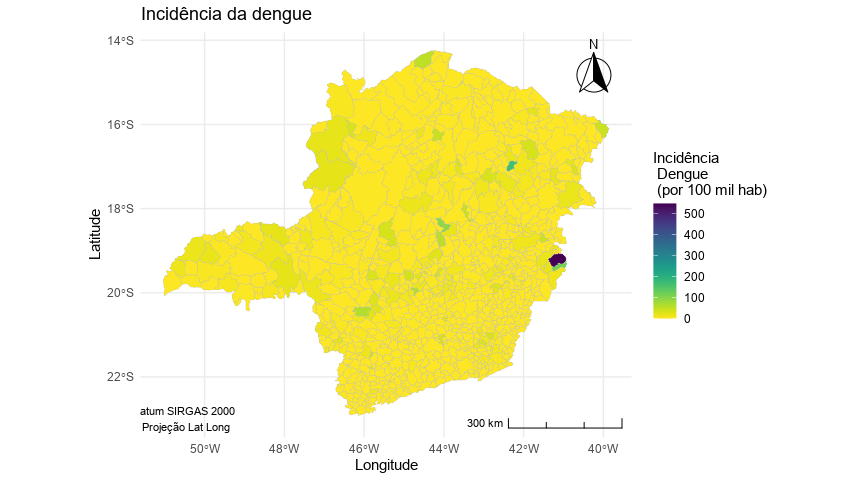

```r
ggplot2::ggplot() +
  ggplot2::geom_sf(
    data = minas_map,
    ggplot2::aes(fill = coef_inc_acum),
    color = '#bdbdbd',
    size = .1) +
  viridis::scale_fill_viridis(name = "Incidência \n Dengue \n (por 100 mil hab)",
                              discrete = F,
                              direction = -1) +
  ggspatial::annotation_scale(location = 'br', style = "ticks") +
  ggspatial::annotation_north_arrow(location = 'tr',
                                    style = ggspatial:::north_arrow_fancy_orienteering()) +
  ggplot2::annotate(
    "text",
    x = -50.5,
    y = -23,
    label = "Datum SIRGAS 2000 \n Projeção Lat Long",
    size = 3) +
  ggplot2::theme_minimal() +
  ggplot2::ggtitle("Incidência da dengue") +
  ggplot2::ylab("Latitude") + ggplot2::xlab("Longitude")
```

Analisando a Figura 3, percebe-se um alto número de municípios com a classificação “silencioso”. Essa classificação representa que o município não realizou o processo de notificação de nenhum caso de Dengue à instância estadual. A recomendação é que, mesmo que o município não possua nenhum registro de Dengue, que informe a situação zerada. Tambpem é possível visualizar que a maioria daqueles municípios que não estão classificados como silenciosos, a incidência é baixa.

[figure not shown]

```r
tab_compact_ob <- tab_final |>
  dplyr::filter(!is.na(obito), obito>0) |>
  dplyr::arrange(desc(obito)) |>
  dplyr::mutate(municipio = forcats::fct_reorder(municipio, obito))

gg1 <- ggplot2::ggplot(data = tab_compact_ob,
                ggplot2::aes(x = obito, y = municipio)) +
  ggplot2::geom_col(fill = "#FDE725FF") +
  ggplot2::geom_text(ggplot2::aes(label = obito),
                     hjust = 1.2,
                     color = "black") +
  ggplot2::labs(x = "Número de óbitos",
                y = "Municípios",
                tag = "A",
                title = "Número de óbitos") +
  ggplot2::theme_bw()
```

```r
tab_compact_cs <- tab_final |>
  dplyr::arrange(desc(coef_inc_acum)) |>
  head(10) |>
  dplyr::mutate(municipio = forcats::fct_reorder(municipio, coef_inc_acum))

gg2 <- ggplot2::ggplot(data = tab_compact_cs,
                ggplot2::aes(x = coef_inc_acum, y = municipio)) +
  ggplot2::geom_col(fill = "#1F968BFF") +
  ggplot2::geom_text(ggplot2::aes(label = round(coef_inc_acum, 2)),
                     hjust = 1.2,
                     color = "white") +
  ggplot2::labs(x = "Coeficiente de incidência acumulada",
                y = "Municípios",
                tag = "B",
                title = "Coeficiente de incidência acumulada") +
  ggplot2::theme_bw()
```

**Figura 4. Ranking dos municípios mais acometidos pela Dengue em Minas Gerais.**

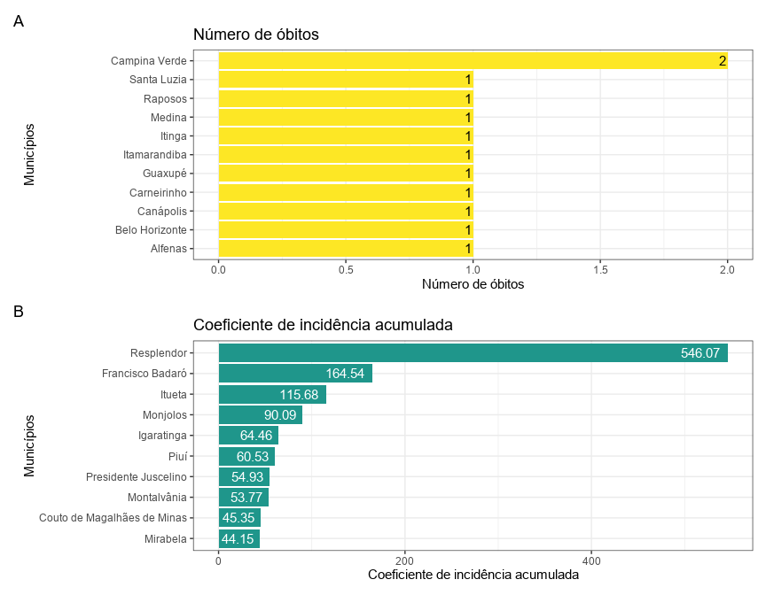

```r
patchwork::wrap_plots(gg1, gg2, nrow = 2)
```

Salvando a base final:

```r
readr::write_csv2(tab_final, "tab_final.csv")
```